# Análisis multivariados

Para evaluar y tratar de explicar las relaciones entre covariables (metadatos) y valores de abundancias de los diferentes ASVs a lo largo de las muestras analizadas, se realizan análisis multivariados. A continuación se presenta un flujo de trabajo para realizar un análisis de componentes principales (PCA), un escalamiento multidimensional no paramétrico (nMDS), un análisis de correspondencia canónica (CCA), y un análisis de redundancia canónica (RDA). Se presentan a su vez pequeñas definiciones de cada análisis, no obstante, se invita a realizar una revisión en caso de dudas o no estar familiarizado con alguno de ellos.

# Análisis de Componentes Principales (PCA)

Esta técnica estadística de reducción de dimensionalidad transforma un conjunto de variables posiblemente correlacionadas en un conjunto más pequeño de variables no correlacionadas llamadas componentes principales. Permite identificar patrones en los datos y resaltar las variaciones más significativas, lo que es especialmente útil para visualizar y analizar conjuntos de datos complejos y de alta dimensión. Cada componente principal explica un porcentaje de la varianza de los datos, siendo el primero el que más varianza explica y el último el que menos explica. ([Jolliffe](https://doi.org/10.1098/rsta.2015.0202) et al., 2016).

## Cargar librerías

```r
#Para llevar a cabo los análisis se necesitan las siguientes paqueterías de R
  library(permute)
  library(lattice)
  library(vegan)
  library(ggplot2)
  library(ggcorrplot)
  library(ggfortify)
  library(readxl)
  library(dplyr)
  library(plotly)
  library(ggrepel)
```

## Importar tablas para análisis

Para los análisis multivariados se necesitan la tabla de abundancias generada en el flujo de trabajo con *DADA2*, los metadatos de las muestras, y la tabla de taxonomía.

```r
#Importar las tablas usando la ruta que apunte a los archivos
  tax <- read.delim("/Users/adriantorres/Desktop/UNIVERSIDAD/SERVICIO/secuencias/Tablas/ASVs_taxonomy_silva.csv")
  abu <- read.delim("/Users/adriantorres/Desktop/UNIVERSIDAD/SERVICIO/secuencias/Tablas/ASVs_counts_silva.csv")
  meta <- readxl::read_excel("/Users/adriantorres/Desktop/UNIVERSIDAD/SERVICIO/secuencias/Tablas/ASVs_metadata.xlsx")
```

## Acomodo de tablas

Para realizar análisis multivariados, los metadatos y la tabla de abundancias necesitan tener el mismo formato. En este caso se organizan las muestras en las filas de las tablas, y las abundancias o covariables a lo largo de las columnas.

```r
#Asignamos los ASVs como los nombres de filas y eliminamos esa columna para evitar redundancias
  rownames(abu)<-abu$X
  abu<-abu[-1]
#Insertamos la columna con el taxón de fila
  abu$Family <- tax$Family
#Reemplazar NAs por No Clasificados
  abu <- abu %>%
    mutate(Family = if_else(is.na(Family), "No Clasificados", Family))
#Agrupamos toda la información por medio de esa columna (elimina filas repetidas sumando todas las abundancias de la misma familia)
  data <- aggregate(. ~ Family, data = abu, sum)
#Ahora aplicamos rownames a data para tener las familias ahi
  rownames(data) <- data$Family
  data <- data[-1]
#Se transpone la tabla para que sea el mismo formato que la metadata
  data <- t(data)
#Le damos el nombre de las muestras a la metadata
  meta <- as.data.frame(meta)
  rownames(meta) <- meta$sample_id
#En este punto data corresponde a nuestras abundancias, mientras que meta corresponde a nuestros metadatos.
```

## Realizar el PCA

El Análisis de Componentes Principales ayuda a representar los datos obtenidos, asi como los comportamientos de las covariables, en un plano bidimensional.

```r
# La función prcomp sirve para realizar un PCA
  pca_result <- prcomp(data)
# Calcula los scores (coordenadas de las muestras en los componentes)
  scores <- as.data.frame(pca_result$x)
# Calcula las correlaciones de las variables ambientales con los componentes principales
  env_vectors <- as.data.frame(cor(meta[,5:8], scores))
# Escala las correlaciones para visualizarlas mejor en el gráfico
  env_vectors <- env_vectors * max(abs(scores))
# Combina la información de las muestras con los resultados del PCA
  pca_data <- cbind(scores, meta)
# Calcula la varianza explicada por cada componente
  explained_variance <- summary(pca_result)$importance[2, ] * 100
  labels <- paste0("PC", 1:2, " (", round(explained_variance[1:2], 1), "%)")
```

## Graficar el PCA

Para observar el acomodo de las muestras y las tendencias de las covariables, se procede a graficar el PCA con ayuda de ggplot2. Para que el gráfico sea más integral, se colorean las muestras de acuerdo al factor tiempo, y se les asigna una forma según el factor condición.

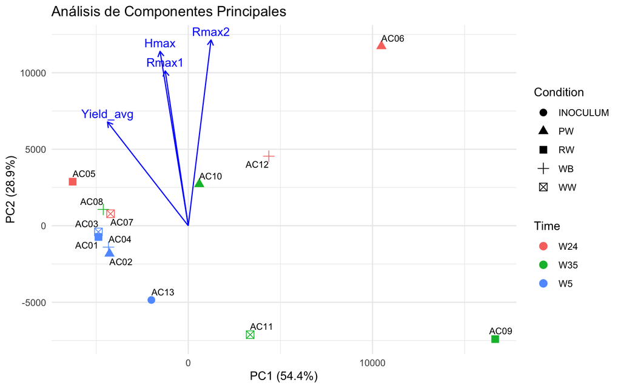

```r
#Para graficar el PCA, se colorean los puntos por tiempo (time) y se les asigna una forma según la condición que contienen en sus metadatos (condition)
  pca_graph <- ggplot(pca_data, aes(x = PC1, y = PC2)) +
  geom_point(aes(color = time, shape = condition), size = 3) +
  geom_text_repel(aes(label=sample_id), max.overlaps = 10, size = 3) +
  geom_segment(data = env_vectors,
               aes(x = 0, y = 0, xend = PC1, yend = PC2),
               arrow = arrow(length = unit(0.2, "cm")),
               color = "blue") +
  geom_text(data = env_vectors,
            aes(x = PC1, y = PC2,
                label = rownames(env_vectors)),
            vjust = -0.5, color = "blue") +
  labs(title = "Análisis de Componentes Principales",
       x = labels[1],
       y = labels[2],
       color = "Time",
       shape = "Condition"
       ) +
  theme_minimal()
#Para visualizar el gráfico se corre la siguiente línea
  pca_graph
```

## Guardar figura

```r
#Para guardar las figuras dentro de nuestro directorio manteniendo un orden, creamos una nueva subcarpeta
  path<-"/Users/adriantorres/Desktop/UNIVERSIDAD/SERVICIO/secuencias"
  subfolder <- "graficas"
  subfolder_path <- file.path(path, subfolder)
#En caso de repetir este código en algun otro momento, le añadimos una función lógica para evitar crear varias veces la misma subcarpeta
  if (!dir.exists(subfolder_path)) {
  dir.create(subfolder_path)
  }
# Guardar las gráficas en la subcarpeta
  ggsave(file.path(subfolder_path, "pca.svg"), plot = pca_graph, dpi = 600)
  ggsave(file.path(subfolder_path, "pca.jpg"), plot = pca_graph, dpi = 600)
  ggsave(file.path(subfolder_path, "pca.pdf"), plot = pca_graph, dpi = 600)
```

# Escalamiento Multidimensional No Paramétrico (nMDS)

En esta técnica de ordenación multivariante se representa gráficamente la similitud o disimilitud entre muestras en un espacio de menor dimensión, manteniendo las relaciones de las distancias lo mejor posible.

## Matriz de distancia

Para generar un nMDS se necesita realizar una matriz de distancia entre las diferentes especies y abundancias a lo largo de las muestras. En este caso, se usa el índice de disimilitud de Bray-Curtis.

```r
  distancia <- vegdist(data, method = "bray")
```

## Realizar el nMDS

Con ayuda de la función metaMDS del paquete vegan, se pueden obtener las coordenadas de las muestras analizadas.

```r
  nmds_result <- metaMDS(distancia, k = 2)
```

Se puede obtener el estrés del modelo para ver que tan aceptable es (idealmente menor a 0.2)

```r
 nmds_result$stress
```

```
## [1] 0.06834651
```

```r
#Se obtienen las coordenadas
  nmds_coords <- as.data.frame(scores(nmds_result))
  nmds_coords$Grupo <- rownames(nmds_coords)
  nmds_coords$Time <- meta$time
```

## Graficar el nMDS

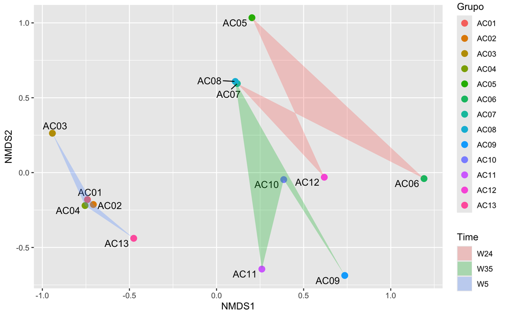

```r
#Graficar los puntos del NMDS junto con las flechas
  nmds_graph <- ggplot(nmds_coords, aes(x = NMDS1, y = NMDS2)) +
    geom_point(aes(color = Grupo), size = 3) +
    geom_text_repel(aes(label = Grupo), hjust = 1.2, vjust = 1.2) +
    geom_polygon(aes(group = Time, fill = Time), alpha = 0.3)
#Se procede a visualizar el gráfico
  nmds_graph
```

## Guardar figura

Como ya se ha creado la subcarpeta para guardar las figuras del PCA, ahora solamente se necesita guardar el gráfico del nMDS en esa subcarpeta.

```r
#Guardar las gráficas en la subcarpeta
  ggsave(file.path(subfolder_path, "nmds.svg"), plot = nmds_graph, dpi = 600)
  ggsave(file.path(subfolder_path, "nmds.jpg"), plot = nmds_graph, dpi = 600)
  ggsave(file.path(subfolder_path, "nmds.pdf"), plot = nmds_graph, dpi = 600)
```

# Análisis de Correspondencia Canónica (CCA)

Esta técnica multivariante analiza la relación entre dos matrices: una de respuesta (como abundancias de especies) y otra de predictores (como variables ambientales). Su objetivo principal es identificar gradientes ambientales que expliquen la distribución de las especies. Combina ideas de regresión y análisis de correspondencia para maximizar la correlación entre los datos, produciendo una representación visual que facilita la interpretación de las relaciones ecológicas complejas ([Ter Braak](https://doi.org/10.2307/1938672), 1986).

```r
#Para realizar el CCA primero debemos establecer tiempo y condición como factores
meta$time <- as.factor(meta$time)
meta$condition <- as.factor(meta$condition)
```

## Realizar el CCA

```r
  cca_model <- cca(data ~ ., data = meta[,5:8])
  summary(cca_model)
  vectors <- envfit(cca_model, meta[, 5:8], perm = 999)
#Coordenadas de las muestras
  sites_scores <- as.data.frame(scores(cca_model, display = "sites"))
#Coordenadas de las especies
  species_scores <- as.data.frame(scores(cca_model, display = "species"))
#Variables de los metadatos
  vectors_df <- as.data.frame(vectors$vectors$arrows * vectors$vectors$r)
  vectors_df$var <- rownames(vectors_df)
# Añadir metadatos (como 'time') a las coordenadas de las muestras
  sites_scores$time <- meta$time
  sites_scores$condition <- meta$condition
#Revisar el porcentaje de varianza explicado por cada eje
  eigen <- eigenvals(cca_model)*100
  labels <- paste0("CCA", 1:2, " (", round(eigen[1:2], 1), "%)")
```

[output not shown]

## Graficar el CCA

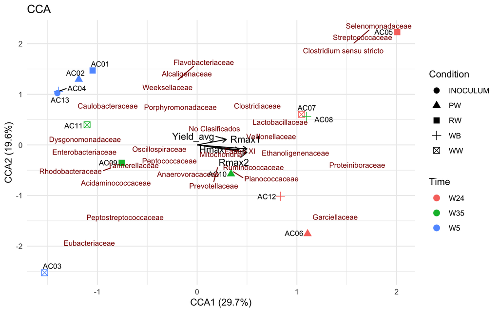

```r
cca_graph <- ggplot() +
  geom_point(data = sites_scores,
             aes(x = CCA1, y = CCA2,
                 color = time, shape = condition),
             size = 3) +
  geom_text_repel(data = sites_scores,
                  aes(x = CCA1, y = CCA2,
                      label = rownames(sites_scores)),
                  hjust = -0.2, vjust = 0.5, size = 3,
                  color = "black") +
  geom_segment(data = vectors_df,
               aes(x = 0, y = 0, xend = CCA1, yend = CCA2),
               arrow = arrow(length = unit(0.2, "cm")),
               color = "black") +
  geom_text_repel(data = vectors_df,
            aes(x = CCA1, y = CCA2, label = var),
            hjust = 1.2, color = "black") +
  geom_text_repel(data = species_scores,
                  aes(x = CCA1, y = CCA2,
                      label = rownames(species_scores)),
                  color = "darkred", size = 3) +
  labs(title = "CCA",
       x = labels[1],
       y = labels[2],
       color = "Time",
       shape = "Condition") +
  theme_minimal()
#Para visualizar el CCA se llama a la variable con el gráfico
  cca_graph
```

## Guardar figura

```r
#Guardar las gráficas en la subcarpeta
  ggsave(file.path(subfolder_path, "cca.svg"), plot = cca_graph, dpi = 600)
  ggsave(file.path(subfolder_path, "cca.jpg"), plot = cca_graph, dpi = 600)
  ggsave(file.path(subfolder_path, "cca.pdf"), plot = cca_graph, dpi = 600)
```

# Análisis de Redundancia Canónica (RDA)

El análisis de redundancia canónica (RDA) es una técnica estadística multivariada que combina análisis de componentes principales y regresión múltiple para explorar cómo un conjunto de variables explicativas cuantitativas influye en un conjunto de variables de respuesta. Permite identificar cómo las variables predictoras explican la variación en las variables respuesta, bajo el supuesto de relaciones lineales, siendo útil para evaluar patrones ecológicos y adaptativos en distintos contextos ([Blanchet](https://doi.org/10.1016/j.ecolmodel.2008.04.001), 2008).

## Realizar el RDA

```r
  rda_model <- rda(data ~ ., data = meta[,5:8])
#Prueba global de significancia del modelo
  anova(rda_model)
#Prueba de significancia de los ejes
  anova(rda_model, by = "axis")
```

[output not shown]

```r
#Coordenadas de las muestras
  sites_scores <- as.data.frame(scores(rda_model, display = "sites"))
#Coordenadas de las especies
  species_scores <- as.data.frame(scores(rda_model, display = "species"))
  species_scores$species <- rownames(species_scores)
#Coordenadas de vectores de las variables explicativas
  env_vectors <- as.data.frame(scores(rda_model, display = "bp"))
  env_vectors$var <- rownames(env_vectors)
#Agregar los factores para su agrupación en el gráfico
  sites_scores$time <- meta$time
  sites_scores$condition <- meta$condition
#Observar el porcentaje de varianza explicado por los ejes
  prop_explained <- eigenvals(rda_model)*100 / sum(eigenvals(rda_model))
  labels <- paste0("RDA", 1:2, " (", round(prop_explained[1:2], 1), "%)")
```

## Graficar el RDA

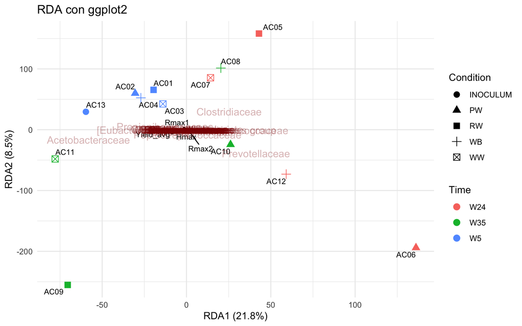

```r
num_species <- nrow(species_scores) + 3 # Número de especies
species_colors <- rainbow(num_species) # Vector de colores

rda_graph <- ggplot() +
  geom_point(data = sites_scores,
             aes(x = RDA1, y = RDA2,
                 color = time,
                 shape = condition),
             size = 3) +
  geom_text_repel(data = sites_scores,
                  aes(x = RDA1, y = RDA2,
                      label = rownames(sites_scores)),
                  size = 3,
                  color = "black") +
  geom_segment(data = env_vectors,
               aes(x = 0, y = 0,
                   xend = RDA1,
                   yend = RDA2),
               arrow = arrow(length = unit(0.2, "cm")),
               color = "black") +
  geom_text_repel(data = env_vectors,
            aes(x = RDA1, y = RDA2,
                label = var),
            hjust = 1.2,
            color = "black", size = 3) +
  geom_text(data = species_scores,
            aes(x = RDA1, y = RDA2,
                label = rownames(species_scores)),
            color = "darkred", size = 4, alpha = 0.3) + #Con alpha modificas opacidad
  labs(title = "RDA con ggplot2",
       x = labels[1], y = labels[2],
       color = "Time", shape = "Condition") +
  theme_minimal()
#Visualización del gráfico
  rda_graph
```

## Guardar figura

```r
# Guardar las gráficas en la subcarpeta
  ggsave(file.path(subfolder_path, "rda.svg"), plot = rda_graph, dpi = 600)
  ggsave(file.path(subfolder_path, "rda.jpg"), plot = rda_graph, dpi = 600)
  ggsave(file.path(subfolder_path, "rda.pdf"), plot = rda_graph, dpi = 600)
```